# How do social scientists collect data to answer the questions?

PSCI 2270 - Week 3

Georgiy Syunyaev

Department of Political Science, Vanderbilt University

September 17, 2024

## Plan for this week

1. Learning about population from sample
2. Descriptive statistics
3. Some math…

## Plan for this week

1. Learning about population from sample

## From individual to population

- We are usually interested in making inferences about groups of units, population
  - *Example: all voters in specific election; all conflicts; all legislators in a country*
- To do so we collect multiple individual measurements
  - *Individual measurement = exact value + chance error + bias*
- Once we we aggregate the formula becomes *estimate = estimand + noise + bias*
  - Estimate: aggregate of individual measures
  - Estimand: population quantity of interest
  - Noise: aggregate of individual chance errors
  - Bias: aggregate systematic error

## Sampling

- We often cannot survey or measure outcome among the whole set of units we are interested in $\Rightarrow$ Target population
  - Example: *People who will vote in the next election; All news reports from Fox News*
- We then have to resort to a subset of units that we can reasonably collect data for $\Rightarrow$ Sample
  - Example: *Those who participate in the survey; News reports that we can download online on a specific date*
- We collect the sample from the available list *that ideally includes the whole population* $\Rightarrow$ Sampling frame
  - Example: *List of registered voters; All news reports ever published online*

## Learning about populations

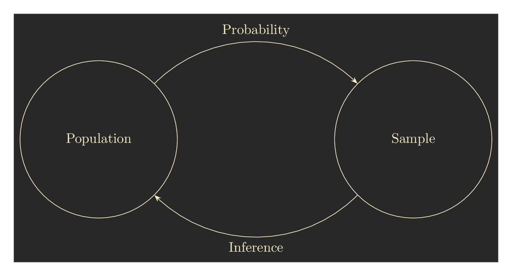

- Probability: characterize the uncertainty about how we collect our data
- Inference: learning about the population from a set of data

## Sources of bias

- Reliability and validity are still a concern
  - a small sample of non-reliable measures could still be off-target
  - *any* sample of non-valid measures will be off-target
- In addition sampling brings more sources of bias:
  - Selection bias: our sampling frame is wrong
  - Non-response bias: we are more/less likely to observe certain types of units (people, documents, conflicts, etc.)
- Even if our sample is free of these biases, we don’t know how representative is our sample

## Types of sampling

- Probability sampling: Every unit in the population has a known probability of being selected into sample
- Simple random sampling: Every unit has an equal selection probability
  - e.g. random digit dialing (RDD):
    1. Take a particular area code + exchange: 617-495-XXXX.
    2. Randomly choose each digit in XXXX to call a particular phone.
    3. Every phone number in America has an equal chance of being included in sample.
  - …or random walk (?)
- *Quota sampling, cluster sampling, snowball sampling, etc.*
- Non-probability sampling: e.g. Opt-in Internet panels

## 1936 Literary Digest Poll

[figure not shown]

- Literary Digest predicted elections using mail-in polls
- Primary source of addresses: Automobile registrations, phone books, country club memberships
- In 1936, sent out 10 million ballots, over 2.3 million returned
- George Gallup sampled 50,000 respondents from all voting age citizens

## Poll’s Result: Fail!

| Pollster | FDR’s Vote Share |
| --- | --- |
| Literary Digest | 43% |
| George Gallup | 56% |
| **Actual Outcome** | 62% |

- Ballots skewed toward the wealthy (with cars, phones) $\Rightarrow$ selection bias
  - Only 1 in 4 households had a phone in 1936.
- In addition, people who respond could be different than those who don’t $\Rightarrow$ non-response bias
- When selection procedure is biased, adding more observations doesn’t help (we keep shooting off-target)

## 1948 Election

[figure not shown]

## The Polling Disaster

| Pollster | Truman | Dewey | Thurmond | Wallace |
| --- | --- | --- | --- | --- |
| Crossley | 45% | 50% | 2% | 3% |
| Gallup | 44% | 50% | 2% | 4% |
| Roper | 38% | 53% | 5% | 4% |
| **Actual Outcome** | 50% | 45% | 3% | 2% |

- Quota sampling:
  - fixed quota of certain respondents for each interviewer
  - sample resembles the population on these characteristics
- Most polls concluded ~2 weeks prior to the elections $\Rightarrow$ selection bias
- Republicans easier to interview within quotas (phones, listed addresses, etc.) $\Rightarrow$ non-response bias

## Plan for this week

1. Learning about population from sample
2. Descriptive statistics

## What to DO with Measured Outcomes

- A **variable** is a series of measurements (observations) of some concept
- **Descriptive (summary) statistics** are numerical summaries of those observations
  - If we smart enough, we wouldn’t need them: just look at the list of numbers and completely understand
- Two salient features of a variable that we want to know:
  - **Central tendency:** where is the middle/typical/average value
  - **Spread:** are all observations close to each other or spread out?

## Center of the data: Mean

- *Center* of the data: typical/average value
- **Mean:** sum of the values divided by the number of observations

$$\color{#98971a}{\bar{x}} = \color{#d65d0e}{\frac{1}{n}} \color{#458588}{\sum_{i = 1}^{n} x_{i}}$$

- What’s all this notation?
  - Population value: Greek letters
  - Sample value: Latin letters or greek letters with hat
  - Miscellaneous squiggles (sums, hats, bars, subscripts)
- Applied to the mean:
  - Population value: $\mu$ (say *mu*)
  - Sample value: $\hat{\mu}$ (say *mu-hat*); $\bar{x}$ (say “x-bar”)

## Center of the data: Median

- **Median:**
  $$\text{median} = \begin{cases}
  \text{middle value} & \text{if number of entries is odd} \\
  \frac{\text{sum of two middle values}}{2} & \text{if number of entries is even}
  \end{cases}$$
- Median more robust to **outliers**:
  - **Example 1:** $\text{data} = \{ 0, 1, 2, 3, 5 \}$. $\text{mean} = 2.2$, $\text{median} = 2$
  - **Example 2:** $\text{data} = \{ 0, 1, 2, 3, 100 \}$. $\text{mean} = 21.2$, $\text{median} = 2$
- **Question:** What does Elon Musk do to the mean vs median income? $\Rightarrow$ income inequality measure

## Spread of the data

- Are the data close to the center?
- **Range:** $\left[ \min (X), \max (X) \right]$
- **Quantile** (quartile, quintile, percentile, etc):
  - 25th percentile = lower quartile (25% of the data below this value)
  - 50th percentile = median (50% of the data below this value)
  - 75th percentile = upper quartile (75% of the data below this value)
- **Interquartile range (IQR):** a measure of variability
  - How spread out is the middle half of the data?
  - Is most of the data really close to the median or are the values spread out?
- One definition of *outliers*: over 1.5 × IQR above the upper quartile or below lower quartile

## Standard deviation

- **Standard deviation (**$\sigma$, sd): On average, how far away are data points from the mean?

$$\text{sd} = \color{#cc241d}{\sqrt{\color{#b16286}{\frac{1}{n - 1}} \color{#98971a}{\sum_{i = 1}^{n}} \color{#458588}{(}\color{#d65d0e}{x_i - \bar{x}}\color{#458588}{)^2} }}$$

- Steps:
  1. Subtract each data point by the mean
  2. Square each resulting difference
  3. Take the sum of these values
  4. Divide by $n − 1$
  5. Take the square root
- **Variance (**$\sigma^2$, var): $\text{Var} = \text{standard deviation}^2$
- **Question:** Why not just take the average deviations from mean without squaring?

## Plan for this week

1. Learning about population from sample
2. Descriptive statistics
3. Some math…

## Some Building Blocks

- **Probability:**
  - Basis for understanding uncertainty in our estimates
  - Statistics is applied probability
- **Law of Large Numbers**
  - Perform the same task over and over (e.g., draw a sample)
  - Average of the results converges to the truth
- **Central Limit Theorem:**
  - Add up a lot of independent factors
  - Result follows the normal distribution

## Large random samples

- In real data, we will have a set of $n$ observations of a variable: $X_1$ , $X_2$, … , $X_n$
  - $X_1$ is the age of the first randomly selected registered voter.
  - $X_2$ is the age of the second randomly selected registered voter, etc.
- Empirical analyses: summary of these $n$ observations
  - All statistical procedures involve a statistic, very often sum or mean.
  - What are the properties of these sums and means?
  - Can the sample mean of age tell us anything about the population distribution of age?
- **Asymptotics:** what can we learn as $n$ gets big?

## Stats Lingo: LLN

**Law of Large Numbers (LLN)**

Let $X_1$ , … , $X_n$ be i.i.d. random variables with mean $\mu$ and finite variance $\sigma^2$. Then, $\bar{X}_{n}$ converges to $\mu$ as $n$ gets large.

## Normal Distribution

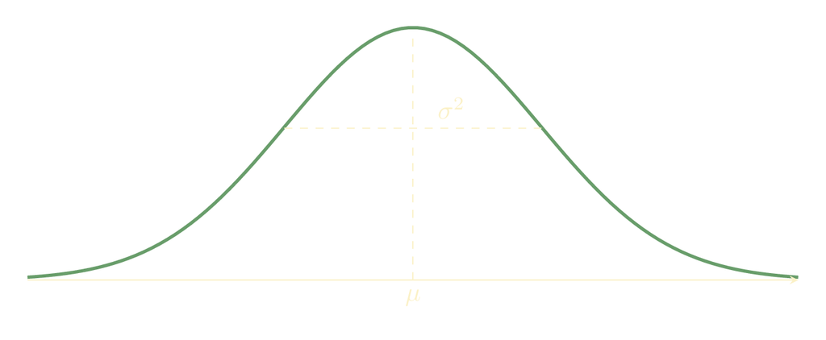

- The normal distribution is the classic “bell-shaped” curve.
  - Extremely ubiquitous in statistics
  - mean and variance follow standard notation
  - When $X$ is distributed normally, we write $X \sim N ( \mu, \sigma^2 )$
- Three key properties:
  - **Unimodal:** one peak at the mean
  - **Symmetric** around the mean
  - **Everywhere positive:** any real value can possibly occur

## Stats Lingo: CLT

**Central Limit Theorem (CLT)**

Let $X_1$ , … , $X_n$ be a statistical sample from population with mean $\mu$ and variance $\sigma^2$. Then, $\bar{X}_n$ (sample mean) will be approximately distributed $N ( \mu, \sigma^2 / n )$ as $n$ goes to infinity.

- Approximation is better as sample size goes up
- **Important result:** We now know how far away $\bar{X}_n$ can be from its mean!

## Impications of CLT/LLN

  $$SE = \sqrt{\frac{\sigma^2}{n}} = \frac{\sigma}{\sqrt{n}}$$

## Next Week

- Think about possible data strategies for answering **question:** Which factors affect election participation?
- Applying CLT/LLN to get point estimates and estimates of uncertainty
- Comparing group means and logic of causal inference